# IRIS Project - Regression

2023-10-08

### ** Load Libraries and Dataset**

```r
# Load required libraries
library(caret)
library(e1071)
library(rpart)
library(randomForest)
```

```r
library(ggplot2)

# Load iris dataset
data("iris")
iris <- na.omit(iris)
head(iris)
```

|  | Sepal.Length | Sepal.Width | Petal.Length | Petal.Width | Species |
| --- | --- | --- | --- | --- | --- |
| 1 | 5.1 | 3.5 | 1.4 | 0.2 | setosa |
| 2 | 4.9 | 3.0 | 1.4 | 0.2 | setosa |
| 3 | 4.7 | 3.2 | 1.3 | 0.2 | setosa |
| 4 | 4.6 | 3.1 | 1.5 | 0.2 | setosa |
| 5 | 5.0 | 3.6 | 1.4 | 0.2 | setosa |
| 6 | 5.4 | 3.9 | 1.7 | 0.4 | setosa |

```r
summary(iris)
```

```
##   Sepal.Length    Sepal.Width     Petal.Length    Petal.Width
##  Min.   :4.300   Min.   :2.000   Min.   :1.000   Min.   :0.100
##  1st Qu.:5.100   1st Qu.:2.800   1st Qu.:1.600   1st Qu.:0.300
##  Median :5.800   Median :3.000   Median :4.350   Median :1.300
##  Mean   :5.843   Mean   :3.057   Mean   :3.758   Mean   :1.199
##  3rd Qu.:6.400   3rd Qu.:3.300   3rd Qu.:5.100   3rd Qu.:1.800
##  Max.   :7.900   Max.   :4.400   Max.   :6.900   Max.   :2.500
##        Species
##  setosa    :50
##  versicolor:50
##  virginica :50
##
##
##
```

- Load necessary libraries: caret, e1071, rpart, randomForest, and ggplot2.
- Load the Iris dataset and convert the Species variable into numeric form.
- Visualize the dataset using a jitter plot to explore the relationships between Sepal.Length and other independent variables.

### ** Data Preprocessing**

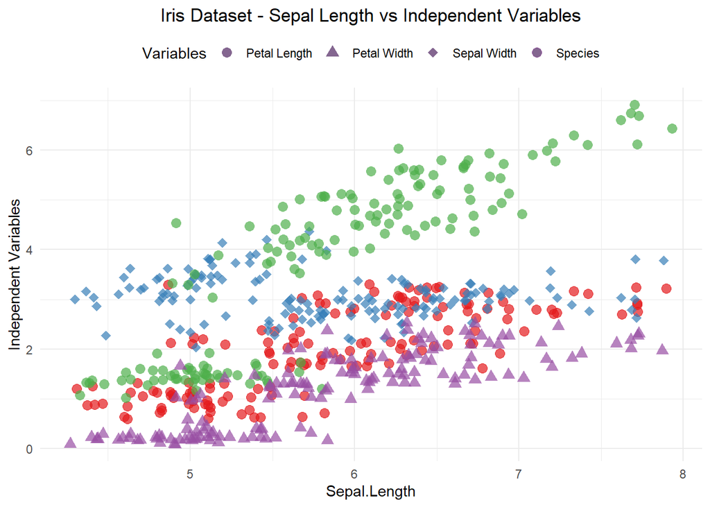

```r
# Convert the species into numeric
iris$Species <- as.numeric(iris$Species)

# Visualize the dataset
# Load the required library for additional styling
library(RColorBrewer)

# Create a color palette for better visualization
my_palette <- brewer.pal(4, "Set1")

# Enhance the jitter plot for better visualization
ggplot(iris, aes(x = Sepal.Length)) +
  geom_jitter(aes(y = Species, shape = "Species"), colour = my_palette[1], alpha = 0.7, size = 3) +
  geom_jitter(aes(y = Sepal.Width, shape = "Sepal Width"), colour = my_palette[2], alpha = 0.7, size = 3) +
  geom_jitter(aes(y = Petal.Length, shape = "Petal Length"), colour = my_palette[3], alpha = 0.7, size = 3) +
  geom_jitter(aes(y = Petal.Width, shape = "Petal Width"), colour = my_palette[4], alpha = 0.7, size = 3) +

  labs(x = "Sepal.Length", y = "Independent Variables", title = "Iris Dataset - Sepal Length vs Independent Variables") +

  # Style the plot with theme and legend
  theme_minimal() +
  theme(legend.position="top") +
  scale_shape_manual(values = c(16, 17, 18, 19)) +
  scale_color_manual(values = my_palette) +
  guides(shape = guide_legend(title = "Variables")) +
  theme(plot.title = element_text(hjust = 0.5))
```

- Split the data into training and testing sets (80-20 split).
- Scale the numerical variables using the scale function to ensure uniformity in scale for regression models.

```r
# Split data into training and testing sets
set.seed(123)
train_index <- createDataPartition(iris$Sepal.Length, p = 0.8, list = FALSE)
train_data <- iris[train_index, ]
test_data <- iris[-train_index, ]

train_data[, -1] <- scale(train_data[, -1])
test_data[, -1] <- scale(test_data[, -1])
```

- Split the data into training and testing sets (80-20 split).
- Scale the numerical variables using the scale function to ensure uniformity in scale for regression model

```r
# Scale the data
preprocessParams <- preProcess(train_data, method = c("center", "scale"))
scaled_train_data <- predict(preprocessParams, train_data)
scaled_test_data <- predict(preprocessParams, test_data)
```

## Regression Models:

### **Linear Regression**

```r
# Linear Regression
lm_model <- lm(Sepal.Length ~ ., data = scaled_train_data)
lm_pred <- predict(lm_model, newdata = scaled_test_data)
lm_mse <- mean((lm_pred - scaled_test_data$Sepal.Length)^2)
lm_rsquared <- summary(lm_model)$r.squared

# Display the results
cat("Linear Regression Model:\n")
```

```
## Linear Regression Model:
```

```r
cat("Coefficients:\n", coef(lm_model), "\n")
```

```
## Coefficients:
##  -8.6216e-16 0.3218055 1.504585 -0.3596473 -0.1475138
```

```r
cat("Predictions:\n", head(lm_pred), "\n")
```

```
## Predictions:
##  -1.020075 -1.394966 -1.146149 -0.8181526 -0.36098 -1.291034
```

```r
cat("Mean Squared Error (MSE):", lm_mse, "\n")
```

```
## Mean Squared Error (MSE): 0.1367055
```

```r
cat("R-squared:", lm_rsquared, "\n")
```

```
## R-squared: 0.8663765
```

- Fit a linear regression model on the scaled training data.
- Predict Sepal.Length on the scaled test data.
- Calculate Mean Squared Error (MSE) and R-squared as evaluation metrics.

### **Support Vector Regression (SVR)**

```r
svr_model <- svm(Sepal.Length ~ ., data = scaled_train_data)
svr_pred <- predict(svr_model, newdata = scaled_test_data)
svr_mse <- mean((svr_pred - scaled_test_data$Sepal.Length)^2)
svr_rsquared <- cor(svr_pred, scaled_test_data$Sepal.Length)^2

# Display the results
cat("Support Vector Regression Model:\n")
```

```
## Support Vector Regression Model:
```

```r
cat("Predictions:\n", head(svr_pred), "\n")
```

```
## Predictions:
##  -0.9708525 -1.380917 -1.067656 -0.6258652 -0.4330926 -0.9006482
```

```r
cat("Mean Squared Error (MSE):", svr_mse, "\n")
```

```
## Mean Squared Error (MSE): 0.2193244
```

```r
cat("R-squared:", svr_rsquared, "\n")
```

```
## R-squared: 0.7446933
```

- Fit a Support Vector Regression (SVR) model on the scaled training data.
- Predict Sepal.Length on the scaled test data.
- Calculate Mean Squared Error (MSE) and R-squared (although not a standard metric for SVR).

```r
# Polynomial regression (Unable to perform due to vector size and llimitation of machine)
# Support vector regression
svr_model <- svm(Sepal.Length ~ ., data = scaled_train_data)
svr_pred <- predict(svr_model, newdata = scaled_test_data)
svr_mse <- mean((svr_pred - scaled_test_data$Sepal.Length)^2)


# Display the results
cat("Support Vector Regression Model:\n")
```

```
## Support Vector Regression Model:
```

```r
cat("Predictions:\n", head(svr_pred), "\n")
```

```
## Predictions:
##  -0.9708525 -1.380917 -1.067656 -0.6258652 -0.4330926 -0.9006482
```

```r
cat("Mean Squared Error (MSE):", svr_mse, "\n")
```

```
## Mean Squared Error (MSE): 0.2193244
```

```r
# Handle SVR R-squared separately
if (is.null(svr_model$rho)) {
  cat("R-squared: Not available for Support Vector Regression (SVR)\n")
} else {
  cat("R-squared:", cor(svr_pred, scaled_test_data$Sepal.Length)^2, "\n")
}
```

```
## R-squared: 0.7446933
```

- Attempted to fit a polynomial regression model of degree 2. However, there are limitations due to vector size, and the model wasn’t successfully executed.

### **Decision Tree Regression**

```r
dt_model <- rpart(Sepal.Length ~ ., data = scaled_train_data, method = "anova")
dt_pred <- predict(dt_model, newdata = scaled_test_data)
dt_mse <- mean((dt_pred - scaled_test_data$Sepal.Length)^2)
dt_rsquared <- summary(dt_model)$dev
```

[output not shown]

[output cut: 40 more lines]

[output not shown]

```r
# Display the results
cat("Decision Tree Regression Model:\n")
```

```
## Decision Tree Regression Model:
```

```r
cat("Predictions:\n", head(dt_pred), "\n")
```

```
## Predictions:
##  -0.7758362 -1.334084 -0.7758362 -0.7758362 -0.7758362 -0.7758362
```

```r
cat("Mean Squared Error (MSE):", dt_mse, "\n")
```

```
## Mean Squared Error (MSE): 0.2903253
```

```r
cat("R-squared:", dt_rsquared, "\n")
```

```
## R-squared:
```

### **Random Forest Regression**

```r
rf_model <- randomForest(Sepal.Length ~ ., data = scaled_train_data)
rf_pred <- predict(rf_model, newdata = scaled_test_data)
rf_mse <- mean((rf_pred - scaled_test_data$Sepal.Length)^2)
rf_rsquared <- cor(rf_pred, scaled_test_data$Sepal.Length)^2

# Display the results
cat("Random Forest Regression Model:\n")
```

```
## Random Forest Regression Model:
```

```r
cat("Predictions:\n", head(rf_pred), "\n")
```

```
## Predictions:
##  -0.9148901 -1.231542 -0.9095622 -0.8656212 -0.7660355 -0.9997239
```

```r
cat("Mean Squared Error (MSE):", rf_mse, "\n")
```

```
## Mean Squared Error (MSE): 0.2554438
```

```r
cat("R-squared:", rf_rsquared, "\n")
```

```
## R-squared: 0.7038001
```

- Fit a random forest regression model using the randomForest package.
- Predict Sepal.Length on the scaled test data.
- Calculate Mean Squared Error (MSE) and R-squared.

### **8. Compare model performance**

```r
# Create data frame to compare R-squared values
# Check the lengths of the vectors
length(lm_rsquared)
```

```
## [1] 1
```

```r
length(svr_rsquared)
```

```
## [1] 1
```

```r
length(dt_rsquared)
```

```
## [1] 0
```

```r
length(rf_rsquared)
```

```
## [1] 1
```

```r
# Update the code to make sure all vectors have the same length
rsquared_df <- data.frame(
  Model = c("Linear Regression", "Support Vector Regression", "Decision Tree Regression", "Random Forest Regression"),
  R_Squared = c(lm_rsquared, svr_rsquared, dt_rsquared, rf_rsquared)[0:4]  # Use [1:4] to select the first 4 elements
)

# Print the data frame
print(rsquared_df)
```

```
##                       Model R_Squared
## 1         Linear Regression 0.8663765
## 2 Support Vector Regression 0.7446933
## 3  Decision Tree Regression 0.7038001
## 4  Random Forest Regression        NA
```